# training and test sets

Filippo Biscarini

7/6/2020

## Reading the data

For this practical session on linear regression we are using a dataset on the relationship between the age of wild bats and DNA methylation at specific CpG sites ([data](https://datadryad.org/stash/dataset/doi:10.5061/dryad.rn0198d); [paper](https://onlinelibrary.wiley.com/doi/abs/10.1111/1755-0998.12925)).

The public dataset downloaded from Dryad is an `.xlsm` file, and can be read into *R* using the `read.xlsx()` function from the **xlsx** package.

```r
ch4 <- read.xlsx("../data/DNA methylation data.xlsm", sheetIndex = 1)
ch4 <- na.omit(ch4[,-c(1,3)])
head(ch4)
```

```
##   Age CpG.1.TET2 CpG.2.TET2 CpG.3.TET2 CpG.4.TET2 CpG.GRIA2.1 CpG.GRIA2.2
## 1   0         29         21         26         31           2           2
## 2   0         30         21         24         32           1           2
## 3   1         44         38         51         53           1           5
## 4   1         48         36         50         46           1           2
## 5   1         22          9         28         31           2           2
## 6   1         42         30         40         41           0           4
##   ASPA.1
## 1     61
## 2     59
## 3     48
## 4     53
## 5     41
## 6     59
```

## Training and testing sets

```r
## sanity checks
nrow(training_set)
```

```
## [1] 47
```

```r
nrow(test_set)
```

```
## [1] 12
```

## Fitting the multiple linear regression model

Note: we use only the **training data** to fit the model!

```r
fit <- lm(Age ~ ., data = training_set)
tidy(fit)
```

```
## # A tibble: 8 x 5
##   term        estimate std.error statistic  p.value
##   <chr>          <dbl>     <dbl>     <dbl>    <dbl>
## 1 (Intercept)  -1.79      3.83      -0.468 0.643
## 2 CpG.1.TET2   -0.0609    0.139     -0.437 0.664
## 3 CpG.2.TET2    0.209     0.130      1.61  0.116
## 4 CpG.3.TET2   -0.111     0.0897    -1.24  0.221
## 5 CpG.4.TET2    0.125     0.0783     1.60  0.118
## 6 CpG.GRIA2.1   0.906     0.233      3.89  0.000384
## 7 CpG.GRIA2.2   0.359     0.220      1.63  0.112
## 8 ASPA.1       -0.0602    0.0398    -1.51  0.138
```

```r
r_squared <- summary(fit)$r.squared
print(paste("R^2", round(r_squared,4)))
```

```
## [1] "R^2 0.7124"
```

The coefficient of determination **$R^2$** is 0.7124088

```r
data.frame("coefficient"=coef(fit))
```

```
##             coefficient
## (Intercept) -1.79163886
## CpG.1.TET2  -0.06091960
## CpG.2.TET2   0.20916572
## CpG.3.TET2  -0.11148306
## CpG.4.TET2   0.12505784
## CpG.GRIA2.1  0.90596854
## CpG.GRIA2.2  0.35893073
## ASPA.1      -0.06015041
```

### The test error

```r
predictions <- predict(fit, newdata = test_set[,-1], interval="none", type = "response", na.action=na.pass)

cbind.data.frame("test_age"=test_set[,1], "predictions"=round(predictions,2))
```

```
##    test_age predictions
## 4         1        1.43
## 11        2        3.61
## 13        2        5.46
## 27        5        8.22
## 34        5        3.83
## 39        6        5.68
## 40        6        1.51
## 41        6        4.46
## 43        6        5.72
## 44        7       10.14
## 48        8        7.85
## 57       12        6.24
```

```r
r_pearson = cor(test_set$Age,predictions)
r_spearman = cor(test_set$Age,predictions, method = "spearman")
mse = mean((test_set$Age-predictions)^2)
rmse = sqrt(mse)
nrmse = sqrt(mse)/mean(test_set$Age)

data.frame("metric"=c("MSE","RMSE","NRMSE","r pearson","r spearman"),
           "value"=c(mse,rmse,nrmse,r_pearson,r_spearman))
```

```
##       metric     value
## 1        MSE 7.6901936
## 2       RMSE 2.7731198
## 3      NRMSE 0.5042036
## 4  r pearson 0.4683920
## 5 r spearman 0.6215713
```

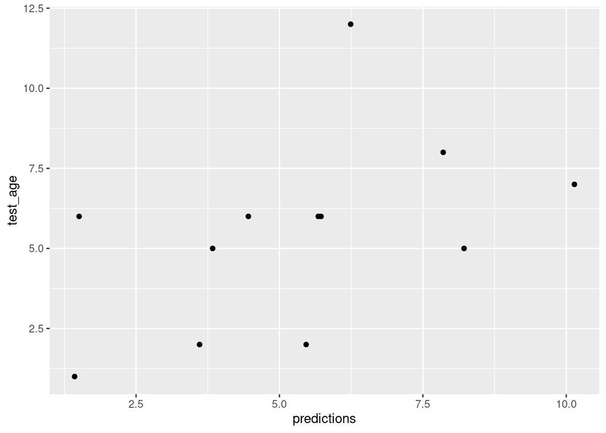

```r
ggplot(data.frame("test_age"=test_set$Age,"predictions"=predictions), aes(x=predictions,y=test_age)) + geom_point()
```

### The training error

We can compare the test error measured above with the training error, i.e. the model performance measured on the training data:

```r
predictions <- predict(fit, newdata = training_set[,-1], interval="none", type = "response", na.action=na.pass)
```

```r
r_pearson = cor(training_set$Age,predictions)
r_spearman = cor(training_set$Age,predictions, method = "spearman")
mse = mean((training_set$Age-predictions)^2)
rmse = sqrt(mse)
nrmse = sqrt(mse)/mean(training_set$Age)

data.frame("metric"=c("MSE","RMSE","NRMSE","r pearson","r spearman"),
           "value"=c(mse,rmse,nrmse,r_pearson,r_spearman)) %>% kable()
```

| metric | value |
| --- | --- |
| MSE | 3.8395833 |
| RMSE | 1.9594855 |
| NRMSE | 0.3611601 |
| r pearson | 0.8440431 |
| r spearman | 0.8148278 |

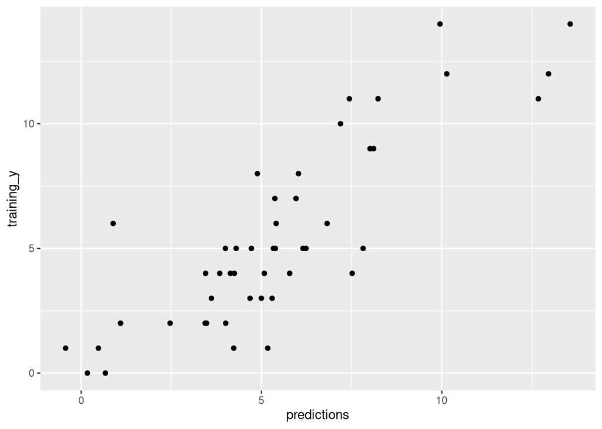

```r
ggplot(data.frame("training_y"=training_set$Age,"predictions"=predictions), aes(x=predictions,y=training_y)) + geom_point()
```

## Exercise 3.1

- try different training/testing sets
- measure the performance of the model

```r
## write your code here
```

## Validation set approach

```
##         MSE     RMSE     NRMSE r pearson r spearman
## 1  9.655564 3.107340 0.5378089 0.6262291  0.5914918
## 2  4.458715 2.111567 0.3800820 0.8399139  0.6421248
## 3  5.510328 2.347409 0.4311567 0.7015409  0.6419091
## 4  5.868859 2.422573 0.4317456 0.6662808  0.5894127
## 5  4.372408 2.091030 0.3840668 0.8731177  0.7813165
## 6  5.783414 2.404873 0.4509137 0.6635211  0.5970532
## 7  9.083869 3.013946 0.4843841 0.6493268  0.6826459
## 8  6.056669 2.461030 0.4259475 0.7997663  0.7437827
## 9  4.640508 2.154184 0.4671724 0.6304235  0.4890777
## 10 6.616062 2.572171 0.4247621 0.7365802  0.7545967
```

We can now summarise and visualise the results:

```r
mDF <- reshape2::melt(df, variable.name = "metric")
mDF %>%
  group_by(metric) %>%
  summarise(N=n(), avg=mean(value), std=sd(value))
```

```
## # A tibble: 5 x 4
##   metric         N   avg    std
##   <fct>      <int> <dbl>  <dbl>
## 1 MSE           20 6.07  1.98
## 2 RMSE          20 2.43  0.411
## 3 NRMSE         20 0.456 0.0858
## 4 r pearson     20 0.720 0.116
## 5 r spearman    20 0.629 0.131
```

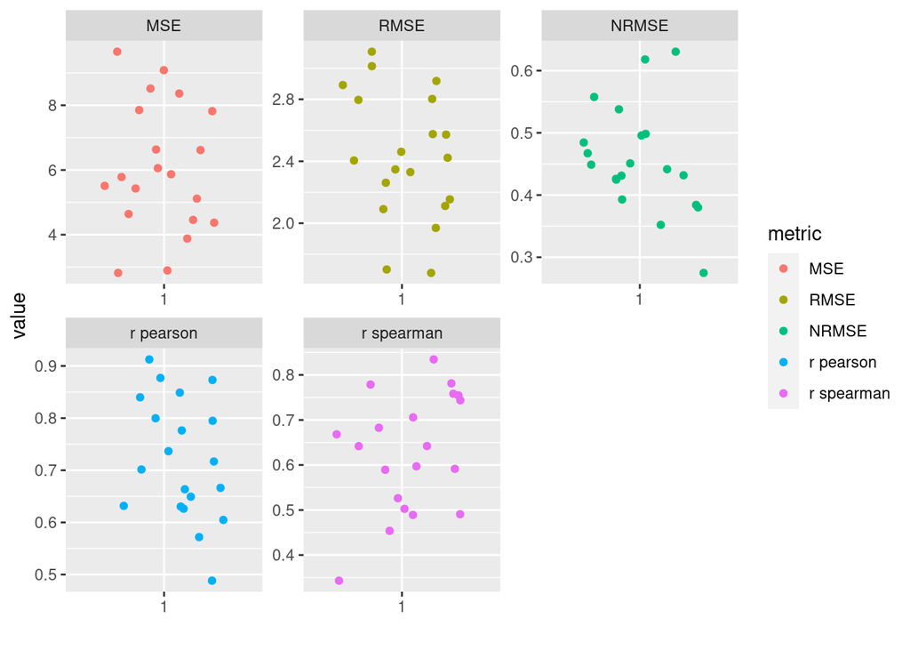

```r
p <- ggplot(mDF, aes(x = factor(1), y = value))
p <- p + geom_jitter(aes(colour=metric))
p <- p + facet_wrap(~metric, scales = "free")
p <- p + xlab("")
p
```

## k-fold cross-validation

Now, we implement 5-fold cross-validation. We set k=5 and then assign each observation from the original dataset to a fold:

```r
n = nrow(ch4)
k = 5
folds <- sample(x = seq(1,k), size = n, replace = TRUE)
table(folds)
```

```
## folds
##  1  2  3  4  5
## 13  5 21  5 15
```

We now fit and evaluate the model *k* times, and save results:

```r
cv.error = data.frame("fold"=NULL,"MSE"=NULL,"RMSE"=NULL,
                   "NRMSE"=NULL,"r_pearson"=NULL,"r_spearman"=NULL)
for(i in 1:k) {

  print(paste("using validation fold",i))
  training_set <- ch4[folds!=i,]
  fit <- lm(Age ~ ., data = training_set)

  test_set <- ch4[folds==i,]
  predictions <- predict(fit, newdata = test_set[,-1], interval="none", type = "response", na.action=na.pass)

  r_pearson = cor(test_set$Age,predictions)
  r_spearman = cor(test_set$Age,predictions, method = "spearman")
  mse = mean((test_set$Age-predictions)^2)
  rmse = sqrt(mse)
  nrmse = sqrt(mse)/mean(test_set$Age)

  res = data.frame("fold"=i,"MSE"=mse,"RMSE"=rmse,
                   "NRMSE"=nrmse,"r_pearson"=r_pearson,"r_spearman"=r_spearman)
  cv.error <- rbind.data.frame(cv.error,res)
}
```

```
## [1] "using validation fold 1"
## [1] "using validation fold 2"
## [1] "using validation fold 3"
## [1] "using validation fold 4"
## [1] "using validation fold 5"
```

```r
kable(cv.error)
```

| fold | MSE | RMSE | NRMSE | r_pearson | r_spearman |
| --- | --- | --- | --- | --- | --- |
| 1 | 9.048346 | 3.008047 | 0.6016094 | 0.5382301 | 0.5853258 |
| 2 | 10.147929 | 3.185581 | 0.5492382 | -0.4983303 | -0.4472136 |
| 3 | 6.212084 | 2.492405 | 0.5081603 | 0.7640990 | 0.6241222 |
| 4 | 3.088891 | 1.757524 | 0.2662915 | 0.8831116 | 0.8720816 |
| 5 | 4.191524 | 2.047321 | 0.3374705 | 0.8897051 | 0.8499719 |

```r
mCV <- reshape2::melt(cv.error, id.vars = "fold", variable.name = "metric")
mCV %>%
  group_by(metric) %>%
  summarise(N=n(),avg = mean(value), std = sd(value))
```

```
## # A tibble: 5 x 4
##   metric         N   avg   std
##   <fct>      <int> <dbl> <dbl>
## 1 MSE            5 6.54  3.03
## 2 RMSE           5 2.50  0.609
## 3 NRMSE          5 0.453 0.144
## 4 r_pearson      5 0.515 0.584
## 5 r_spearman     5 0.497 0.543
```

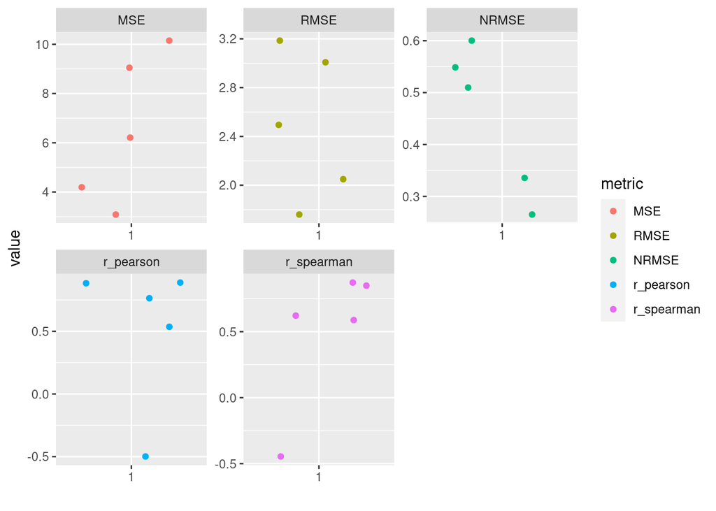

```r
p <- ggplot(mCV, aes(x = factor(1), y = value))
p <- p + geom_jitter(aes(colour=metric))
p <- p + facet_wrap(~metric, scales = "free")
p <- p + xlab("")
p
```

## Exercise 3.2

- implement cross-validation with a different value for k (e.g. k=4, k=10, etc.)

```r
## write your code here
```